# GEOG 5680 6680 01 Introduction to R

Simon Brewer Geography Department University of Utah

13 May, 2024

# Introduction

In this first lab, we’ll do the following:

- Introduce R
- Take a quick tour through some of the features of RStudio and R
- Cover basic importing and exporting data
- Introduce the use of scripts to save (and run) your code

# R

An important point to note at the outset is that R is quite different from other statistical analysis packages (e.g. SPSS, Stata, etc). While these are designed principally for analysis with some programming ability tacked on, R is built from the ground up as a programming language, just one that is designed to make it suitable for data analysis. In this class, we will focus mainly on R as a language, with relatively few examples of specific analyses. The reason for this is that once you understand R’s syntax and structure it is fairly easy to find a function to do a specific analysis. But if you want to go beyond this to do more complex analyses, then you need to understand how to program, in order use to small scripts and functions for this. Or to use Greg Snow’s analogy:

> Using functions in R is like riding a bus. Writing functions in R is like driving a car

> Busses are very easy to use, you just need to know which bus to get on, where to get on, and where to get off (and you need to pay your fare). Cars, on the other hand, require much more work: you need to have some type of map or directions (even if the map is in your head), you need to put gas in every now and then, you need to know the rules of the road (have some type of drivers license). The big advantage of the car is that it can take you a bunch of places that the bus does not go and it is quicker for some trips that would require transferring between busses.

> Using this analogy, programs like SPSS are busses, easy to use for the standard things, but very frustrating if you want to do something that is not already preprogrammed.

> R is a 4-wheel drive SUV (though environmentally friendly) with a bike on the back, a kayak on top, good walking and running shoes in the passenger seat, and mountain climbing and spelunking gear in the back.

> R can take you anywhere you want to go if you take time to learn how to use the equipment, but that is going to take longer than learning where the bus stops are in SPSS. - Greg Snow

R was developed by Ross Ihaka and Robert Gentleman at the University of Auckland in 1992, It was designed to be similar to an existing, commercial language S, developed at Bell Laboratories (formerly AT&T, now Lucent Technologies) by John Chambers and colleagues. R can be considered as a different implementation of S, and is widely used as an educational language and research tool.

The main advantages of R are the fact that it is freeware and that there is a lot of help available online. It is quite similar to other programming packages such as MatLab (not freeware), but more user-friendly than programming languages such as C++ or Fortran. It is also easily extensible, which means that anyone can develop add-on packages to extend the basic functions. There are a large number of these available (ca. 15,000) covering a wide range of analysis types, including many cutting edge methods (many statisticians and data analysts develop their methods in R). We’ll explore some of these later in the week.

In this course we will use R in combination with the RStudio interface (also freeware), which has an organized layout and several extra options. All the code examples will run in base R if you don’t have access to RStudio

## A quick note on formatting

In this and subsequent labs, code that can be entered into R will be highlit, e.g.:

```r
plot(x, y)
```

And R output will be formatted with `##` at the start of the line, for example the output of $5 \times 5$ is:

```
## [1] 25
```

The ‘[1]’ before the output is part of R’s system of indices - here this represents the first value in the output. R functions and parameters mentioned in the main text will use `courier` font. File names will be given in *italics* and will be available in the ‘Datafiles’ directory on the course Canvas site.

# RStudio layout

The RStudio interface consists of several windows. Start RStudio from the ‘Start’ menu under Windows, and the following window should appear (you may not see all of these panels the first time you open it):

[figure not shown]

- Bottom left: console window (also called command window). Here you can type simple commands after the ‘>’ prompt and R will then execute your command. This is the most important window, because this is where R actually does stuff.
- Top left: editor window (also called script window). Collections of commands (scripts) can be edited and saved. The first time you open RStudio, you won’t see this as there are no currently open scripts. When you don’t see this window, you can open it with [File > New > R script]. We’ll look at these scripts in more detail below.
- Top right: workspace / history window. In the workspace window you can see which data and values R has in its memory. You can view and edit the values by clicking on them. The history window shows what has been typed before.
- Bottom right: Files / plots / packages / help window. Here you can open files, view plots (also previous plots), install and load packages or use the help function. You can change the size of the windows by dragging the gray bars between the windows.

# Working with R

Much of your time spent with R will involve typing commands in at the console, and RStudio has some help with this.

- The up/down arrow keys allow you to cycle back through commands that have been previously entered. You can then modify or reuse these as necessary. The commands can also be accessed through the ‘History’ tab in the top-right panel
- The console has “tab-completion”, which allows you to enter the first few characters of a string or function name, press ‘Tab’, and RStudio will bring up a list of possible options that match the string you entered. Try typing `pri` and pressing ‘Tab’ - you should see `print` as part of the list, and you can click on this, or scroll down to use it from the list.

## Workspace

R has a *workspace* where variables and data are stored as you use it. This is held in the memory of the computer, so if you are working from a file, you will need to read it in to the R workspace, and then work on the values held in memory. This means that you only access files to read in or write out data, the rest of the time you are working on a copy in the workspace.

## Working directory

R defines the working directory as the folder in which it is currently working. When you ask R to open a certain file, it will look in the working directory for this file, and when you tell R to save a data file or plot, it will save it in the working directory.

Before you do anything in R, it is important to set your working directory to where all your data and script files are or should be stored. For this class, I recommend making a master directory (e.g. `GEOG5680`), and then make a subdirectory for each module (e.g. `module01`). Now get R to set this directory as the working directory. There are a couple of ways to do this:

You can set the working directory in the console by typing `setwd("directoryname")`. For example:

```r
setwd("C:/GEOG5680/module01")
```

Make sure that the slashes are forward slashes and that you don’t forget the apostrophes. R is case sensitive, so make sure you write capitals where necessary.

Alternatively, in RStudio go to the [Session] menu, then [Set working directory] > [Choose directory…] and browse to your directory. Once you’ve found it, click on it to highlight it, then click [Open].

## Using the console

In the console, the `>` is the prompt, and your commands will be entered here. Click on the console window, then enter the following:

```r
2+2
```

```
## [1] 4
```

And press ‘Enter’, and R will tell you, not too surprisingly, that $2+2=4$. The spacing is not relevant, you could equally enter `2 + 2` or `2+ 2` and get the same result. The `[1]` before the output is a vector index. It refers to the first value in the vector (here a vector of 1). We’ll spend quite a bit of time on these indices in a later class.

We can equally use standard math functions, for example, to take the natural log or square root of 2:

```r
log(2)
sqrt(2)
```

## Variables in R

One of the main ways in which R differs from spreadsheet software is that it uses a *workspace* in the memory of your computer, and the data you use and create is stored there as a *variable*: an *object* with a *name* and a *value*. This first section will introduce the different types of variable and how to manipulate them.

The basic form of a variable in R comes in two parts, the variable name (e.g. `x`) and the value that is attributed to it (e.g. 5). The assignment operators (`=` and `<-`) are used to associate a given value with a variable. For example `x = 5` gives the value 5 to a variable called `x` and creates it if it does not exist (and `x <- 5` does the same thing). Once a variable is created, the value is not fixed and may be modified at anytime, and also may be used in subsequent operations. Note that as you create variables, nothing will appear on the screen. To see the value(s) assigned to any variable, simply type the name at the prompt. Try entering the following commands at the command prompt:

```r
x = 5
x
sqrt(x)
x <- 9
x
sqrt(9)
```

We can create another variable to store the output of any analysis in R:

```r
y = sqrt(x)
y
```

```
## [1] 3
```

```r
ls()
```

```
## [1] "img" "x"   "y"
```

Or go to the ‘Environment’ tab in the top right panel.

# Data import and export

R can read a variety of different file types, and we’ll illustrate a few examples here. You’ll need to download the following files from Canvas

- *iris.csv*
- *co2_mm_mlo.txt*
- *sleep.sav*

Once you have downloaded these from Canvas, move them to the working directory (`GEOG5680/module01`) you created earlier. Make sure that R is using this as a working directory by typing

```r
getwd()
```

```
## [1] "/Users/u0784726/Dropbox/Data/devtools/geog5680/01 Data import export"
```

If this gives you a different directory, make sure to change it to the correct one!

Now make sure that the files you downloaded are in this directory by typing

```r
list.files()
```

And you should see a list including the three files. If not, check that you have moved them to the correct location on your computer, and check again that the working directory is correctly set. Incorrectly setting the working directory is a very common problem when starting working with R, so don’t worry if this takes you a couple of tries. [It’s can also be a problem for people who’ve been working with R for a while…]

## CSV files

Comma-separated value (csv) files are one of the most commonly used formats, as these can be written from and read by Excel, giving you an easy way to transfer between R and Excel. The main function to read these is `read.csv()`. The following command will read the *iris.csv* file in to R:

```r
read.csv("iris.csv")
```

You’ll notice that the contents of the file are displayed in the console. This means that the file was read in correctly, but is not stored. To store these, use the assignment operator to store the file contents in a variable called `iris`:

Now read in the file

```r
iris <- read.csv("iris.csv")
```

And check to see the variable `iris` that has been created in the R workspace

```r
ls()
```

```
## [1] "img"  "iris" "x"    "y"
```

R will store data read in a *dataframe* (we’ll look in detail at what this is in the next module). If you now type:

```r
head(iris)
```

```
##   Sepal.Length Sepal.Width Petal.Length Petal.Width Species Code
## 1          5.1         3.5          1.4         0.2  setosa    1
## 2          4.9         3.0          1.4         0.2  setosa    1
## 3          4.7         3.2          1.3         0.2  setosa    1
## 4          4.6         3.1          1.5         0.2  setosa    1
## 5          5.0         3.6          1.4         0.2  setosa    1
## 6          5.4         3.9          1.7         0.4  setosa    1
```

This will show you the first few lines of the dataframe, and we can also get a brief overview of the dataframe using the `summary()` function. Note that the file contains a mix of data, including numerical values and character strings for the species names.

```r
summary(iris)
```

```
##   Sepal.Length    Sepal.Width     Petal.Length    Petal.Width
##  Min.   :4.300   Min.   :2.000   Min.   :1.000   Min.   :0.100
##  1st Qu.:5.100   1st Qu.:2.800   1st Qu.:1.600   1st Qu.:0.300
##  Median :5.800   Median :3.000   Median :4.350   Median :1.300
##  Mean   :5.843   Mean   :3.057   Mean   :3.758   Mean   :1.199
##  3rd Qu.:6.400   3rd Qu.:3.300   3rd Qu.:5.100   3rd Qu.:1.800
##  Max.   :7.900   Max.   :4.400   Max.   :6.900   Max.   :2.500
##    Species               Code
##  Length:150         Min.   :1
##  Class :character   1st Qu.:1
##  Mode  :character   Median :2
##                     Mean   :2
##                     3rd Qu.:3
##                     Max.   :3
```

One of the main changes in R 4.x is that all character strings are read as characters by default. In previous versions, these were read in as *factors*. This is a specific data type in R used to identify groups of observations. We can reproduce this by modifying the `read.csv()` function as follows.

```r
iris <- read.csv("iris.csv", stringsAsFactors = TRUE)
summary(iris)
```

```
##   Sepal.Length    Sepal.Width     Petal.Length    Petal.Width
##  Min.   :4.300   Min.   :2.000   Min.   :1.000   Min.   :0.100
##  1st Qu.:5.100   1st Qu.:2.800   1st Qu.:1.600   1st Qu.:0.300
##  Median :5.800   Median :3.000   Median :4.350   Median :1.300
##  Mean   :5.843   Mean   :3.057   Mean   :3.758   Mean   :1.199
##  3rd Qu.:6.400   3rd Qu.:3.300   3rd Qu.:5.100   3rd Qu.:1.800
##  Max.   :7.900   Max.   :4.400   Max.   :6.900   Max.   :2.500
##        Species        Code
##  setosa    :50   Min.   :1
##  versicolor:50   1st Qu.:1
##  virginica :50   Median :2
##                  Mean   :2
##                  3rd Qu.:3
##                  Max.   :3
```

CSV files are also a very good way to export data from R. Here we’ll add a new variable to the iris data set containing the petal area of each observed flower. Petals are approximately ellipsoid, so we can use a simple formula of $A=\pi a b$ to estimate area where $a$ is the length and $b$ is the width. Don’t worry too much about this code, we’re just using it to generate a new variable to save:

```r
iris$Petal.Area = pi * iris$Petal.Length * iris$Petal.Width
```

Now we can write the iris data frame out to a new csv file with `write.csv()`:

```r
write.csv(iris, "iris2.csv", row.names = FALSE)
```

If you now check in your working directory, you should see that a new file has been created (*iris2.csv*). Open this in Excel, and you should see that the new variable has been added.

## ASCII text files

Another common format is a simple space or tab delimited text file (extension `*.txt`). We can read these using the `read.table()` function. This is a much more flexible function and can deal with files with different formatting. We’ll use this with the *co2_mm_mlo.txt*, a file containing measurements of atmospheric CO2 from Mauna Loa for the past 60 years. You might want to open this first in a text editor to look at it’s formatting: there are a large number of lines that describe the content of the file before getting to the data. Fortunately, as these start with a `#`, R will ignore them. Unfortunately, this means that it will skip the column headers. We can add our own column names while reading the file as follows:

```r
co2 <- read.table("co2_mm_mlo.txt",
                  col.names = c("year", "month", "decdate", "average",
                                "interpolated", "trend", "ndays"))
head(co2)
```

```
##   year month  decdate average interpolated  trend ndays
## 1 1958     3 1958.208  315.71       315.71 314.62    -1
## 2 1958     4 1958.292  317.45       317.45 315.29    -1
## 3 1958     5 1958.375  317.50       317.50 314.71    -1
## 4 1958     6 1958.458  -99.99       317.10 314.85    -1
## 5 1958     7 1958.542  315.86       315.86 314.98    -1
## 6 1958     8 1958.625  314.93       314.93 315.94    -1
```

If the file does contain column names without a `#`, then you can force R to read them by adding `header = TRUE` in the function.

## Other software

R comes with a set of functions for reading data from other software packages, including most main statistical applications. In order to read an SPSS file (`*.sav`) for example, we can load this library, then use the `read.spss()` function:

```r
library(foreign)
sleep <- read.spss("sleep.sav", to.data.frame = TRUE)
head(sleep)
```

The **foreign** package also has functions to read SAS and Stata output, as well as Data Interchange Format, Epidata and several others.

# R scripts

So far, you have been entering commands in the console to get R to run different functions. However, this can quickly become tedious, especially for complex analysis, or if you make a mistake in a long line of code. A much better practice is to get in the habit of using R scripts to write your code. R scripts are simple text files, which usually contain a set of commands to carry out an analysis. These have several advantages:

- You can transfer your script to any computer with R and re-run your analysis
- If you make a mistake in the middle of 20 lines of code, you just need to fix the mistake and re-run the other lines
- This keeps a copy of your analysis in case you later forget what steps you took
- It makes it easy to re-use or modify existing code for other projects

```r
## My First Script 2020-04-29
## Simple analysis of the iris dataset
```

Next add the code we used above to read in the iris csv file, as well as a print statement to let us know what it is doing:

```
print("Reading file")
iris <- read.csv("iris.csv", stringsAsFactors = TRUE)
```

Now save your file (e.g. `script01.R`). Once saved, we’ll see if it will run. There are a couple of options here.

In the console, you can use the `source()` function to run the script by using the script name

```r
source("script01.R")
```

Or you can highlight all lines in the script and click on the [Run] button at the top right of the script window. Either way, you should see the following appear:

```
## [1] "Reading file"
```

If you don’t see this, check the code, and that you have save the file.

Next, we’ll get the script to print some summary statistics: the mean and standard deviation of one of the variables. Add the following lines to your file (note that we add a comment again so we know what this section is doing):

```
## Summary statistics
print("mean")
print(mean(iris$Sepal.Width))
print("s.d")
print(sd(iris$Sepal.Width))
print("range")
print(range(iris$Sepal.Width))
```

Again, save your script and re-run it using the `source()` command or the [Run] button. Note that if you don’t want to run the entire script, you can run any individual line by highlighting it (or just placing the cursor on it) and clicking [Run]. You can also press [CTRL]+[Enter] on Windows or [CMD]+[Return] on a Mac instead of clicking this button.

Next we’ll add some code to make a simple scatterplot of two of the variables (`Petal.Length` and `Petal.Width`):

```
## Plot petal values
plot(iris$Petal.Length, iris$Petal.Width, pch=16, col=as.factor(iris$Species))
```

Again, save your file and run it, and now you should see this plot appear:

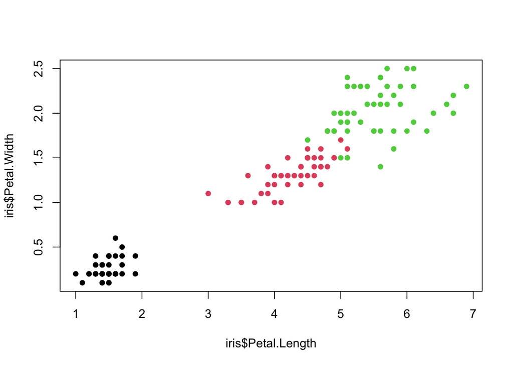

Finally, add the lines to calculate the petal area, and to write out the dataframe to a new file:

```r
## Estimate petal area and save
iris$Petal.Area = pi * iris$Petal.Length * iris$Petal.Width
write.csv(iris, "iris2.csv", row.names = FALSE)
```

# Quitting R

When you are finished with R, exit by typing `q()` in the console (or going to [File > Quit RStudio]). You will be asked if you want to save your workspace. This creates a ‘snap-shot’ of your analysis, with a copy of all the data and the code you have used. In general, I would not recommend doing this, as it can create some large (and hidden) files if you have a lot of data stored. It is generally easier to make sure your code is safely saved in a script, and you can then re-run this the next time you open R.

# Exercise 01

For this module, the only thing to submit is your finished script for the final section. Please change the name of this file to include either your surname or your uID and upload this to Canvas by June 21st [5pts]

# Files used in lab

## *iris.csv*

Fisher’s iris morphology dataset:

| Column header | Variable |
| --- | --- |
| Sepal.Length | Sepal length (mm) |
| Sepal.Width | Sepal width (mm) |
| Petal.Length | Petal length (mm) |
| Petal.Width | Petal width (mm) |
| Species | Species name |
| Code | Species code |

## *co2_mm_mlo.txt*

Observed atmospheric carbon dioxide concentration from Mauna Loa from 1958 to present

| Column header | Variable |
| --- | --- |
| Year | Year |
| Month | Month |
| DecDate | Year-Month as decimal |
| CO2 | CO2 conc. (ppm) |
| CO2int | CO2 conc. with missing values filled |
| Trend | Long-term trend |
| Full | All days in month recorded |